# Assignment 5

Jocelyn Tsai

10/6/2020

```r
library(tidyverse)
library(jtools)
library(interactions)
library(knitr)
```

## List of variables

1. Annual Rainfall in the US (continuous): Total_Rainfall_mm
2. Mean Annual Temperature in the US (continuous): Mean_Temp_Celsius
3. Number of Wildfires in the US each year (continuous): Num_Fires
4. Number of Acres Burned in the US each year (continuous): Acres_Burned
5. Years with Extreme Heat Wave in the US (categorical): Extreme_Heat_Wave
6. Years with High Unemployment in the US (categorical): High_Unemployment

Load data:

```r
US_data <- read_csv("wildfire_dataset.csv")
US_data
```

```
## # A tibble: 87 x 8
##       X1  Year Total_Rainfall_… Mean_Temp_Celsi… Num_Fires Acres_Burned
##    <dbl> <dbl>            <dbl>            <dbl>     <dbl>        <dbl>
##  1     1  1929             661.             6.60    134895     46230000
##  2     2  1930             584.             6.76    190980     52266000
##  3     3  1931             603.             7.59    187214     51607000
##  4     4  1932             656.             6.50    166399     42063000
##  5     5  1933             581.             6.89    140722     43890000
##  6     6  1934             558.             7.83    162663     41821000
##  7     7  1935             638.             6.78    140297     30335000
##  8     8  1936             598.             7.04    226285     43207000
##  9     9  1937             640.             6.88    185209     21981000
## 10    10  1938             646.             7.54    232229     33815000
## # … with 77 more rows, and 2 more variables: Extreme_Heat_Wave <lgl>,
## #   High_Unemployment <lgl>
```

## Model_1: Initial linear regression model

The linear regression model from last assignment predicts the number of wildfires each year based on the annual rainfall, mean annual temperature, number of acres burned, whether the year has extreme heat wave, and whether the year has high unemployment rate. Adjusted R-squared value is 0.3627.

```r
model_1 <- lm(Num_Fires ~ Total_Rainfall_mm + Mean_Temp_Celsius + High_Unemployment + Acres_Burned + Extreme_Heat_Wave, data = US_data)

summary(model_1)
```

```
##
## Call:
## lm(formula = Num_Fires ~ Total_Rainfall_mm + Mean_Temp_Celsius +
##     High_Unemployment + Acres_Burned + Extreme_Heat_Wave, data = US_data)
##
## Residuals:
##    Min     1Q Median     3Q    Max
## -88123 -28791 -10887  25715 155929
##
## Coefficients:
##                         Estimate Std. Error t value Pr(>|t|)
## (Intercept)            4.932e+05  1.026e+05   4.807 6.95e-06 ***
## Total_Rainfall_mm     -3.408e+02  1.323e+02  -2.576   0.0118 *
## Mean_Temp_Celsius     -2.312e+04  1.027e+04  -2.252   0.0271 *
## High_UnemploymentTRUE -3.628e+03  1.033e+04  -0.351   0.7265
## Acres_Burned           2.016e-03  4.222e-04   4.774 7.89e-06 ***
## Extreme_Heat_WaveTRUE -1.098e+04  1.737e+04  -0.633   0.5288
## ---
## Signif. codes:  0 '***' 0.001 '**' 0.01 '*' 0.05 '.' 0.1 ' ' 1
##
## Residual standard error: 44640 on 81 degrees of freedom
## Multiple R-squared:  0.3998, Adjusted R-squared:  0.3627
## F-statistic: 10.79 on 5 and 81 DF,  p-value: 5.695e-08
```

## Model_2: Log transformation

I tested to see if log-transforming the Annual Rainfall variable would improve the model fit, since percentage increases matter as much as absolute increases. Results show that the model fit (adjusted R-squared) slightly improved from 0.3627 (model_1) to 0.363.

```r
model_2 <- lm(Num_Fires ~ log(Total_Rainfall_mm) + Mean_Temp_Celsius + High_Unemployment + Acres_Burned + Extreme_Heat_Wave, data = US_data)

summary(model_2)
```

```
##
## Call:
## lm(formula = Num_Fires ~ log(Total_Rainfall_mm) + Mean_Temp_Celsius +
##     High_Unemployment + Acres_Burned + Extreme_Heat_Wave, data = US_data)
##
## Residuals:
##    Min     1Q Median     3Q    Max
## -87882 -28681 -11233  26020 156326
##
## Coefficients:
##                          Estimate Std. Error t value Pr(>|t|)
## (Intercept)             1.706e+06  5.473e+05   3.117  0.00253 **
## log(Total_Rainfall_mm) -2.214e+05  8.573e+04  -2.583  0.01160 *
## Mean_Temp_Celsius      -2.321e+04  1.026e+04  -2.263  0.02633 *
## High_UnemploymentTRUE  -3.483e+03  1.034e+04  -0.337  0.73710
## Acres_Burned            2.014e-03  4.223e-04   4.769 8.06e-06 ***
## Extreme_Heat_WaveTRUE  -1.137e+04  1.741e+04  -0.653  0.51546
## ---
## Signif. codes:  0 '***' 0.001 '**' 0.01 '*' 0.05 '.' 0.1 ' ' 1
##
## Residual standard error: 44630 on 81 degrees of freedom
## Multiple R-squared:    0.4,  Adjusted R-squared:  0.363
## F-statistic:  10.8 on 5 and 81 DF,  p-value: 5.612e-08
```

## Model_3: Converting continuous variable to categorical variable

Results show that the adjusted R-squared value actually decreases from 0.363 (model_2) to 0.3446 when I convert mean annual temperature to a categorical variable.

```r
median(US_data$Mean_Temp_Celsius)
```

```
## [1] 7.064091
```

```r
US_data <- US_data %>%
  mutate(Categorical_Temp = case_when(Mean_Temp_Celsius == 7.064091 ~ "median temp",
                               Mean_Temp_Celsius < 7.064091 ~ "low temp",
                               Mean_Temp_Celsius > 7.064091 ~ "high temp"))

model_3 <- lm(Num_Fires ~ log(Total_Rainfall_mm) + Categorical_Temp + High_Unemployment + Acres_Burned + Extreme_Heat_Wave, data = US_data)

summary(model_3)
```

```
##
## Call:
## lm(formula = Num_Fires ~ log(Total_Rainfall_mm) + Categorical_Temp +
##     High_Unemployment + Acres_Burned + Extreme_Heat_Wave, data = US_data)
##
## Residuals:
##    Min     1Q Median     3Q    Max
## -89163 -27826 -10096  25833 146295
##
## Coefficients:
##                            Estimate Std. Error t value Pr(>|t|)
## (Intercept)               1.698e+06  5.562e+05   3.053  0.00307 **
## log(Total_Rainfall_mm)   -2.469e+05  8.569e+04  -2.881  0.00507 **
## Categorical_Templow temp  1.673e+04  1.017e+04   1.645  0.10378
## High_UnemploymentTRUE    -2.411e+03  1.052e+04  -0.229  0.81928
## Acres_Burned              1.977e-03  4.325e-04   4.572 1.71e-05 ***
## Extreme_Heat_WaveTRUE    -1.632e+04  1.736e+04  -0.940  0.34990
## ---
## Signif. codes:  0 '***' 0.001 '**' 0.01 '*' 0.05 '.' 0.1 ' ' 1
##
## Residual standard error: 45270 on 81 degrees of freedom
## Multiple R-squared:  0.3827, Adjusted R-squared:  0.3446
## F-statistic: 10.04 on 5 and 81 DF,  p-value: 1.667e-07
```

## Model_4: Adding an interaction term

I added Extreme_Heat_Wave (whether a year has extreme heat wave or not) as an interaction term because I am guessing that independent variables such as annual rainfall, mean annual temperature, or number of acres burned might depend on whether the year has extreme heat wave.

```r
model_4 <- lm(Num_Fires ~ log(Total_Rainfall_mm) + Mean_Temp_Celsius + High_Unemployment + Acres_Burned + Extreme_Heat_Wave +
                log(Total_Rainfall_mm):Extreme_Heat_Wave +
                Mean_Temp_Celsius:Extreme_Heat_Wave +
                High_Unemployment:Extreme_Heat_Wave +
                Acres_Burned:Extreme_Heat_Wave,
                data = US_data)

summary(model_4)
```

```
##
## Call:
## lm(formula = Num_Fires ~ log(Total_Rainfall_mm) + Mean_Temp_Celsius +
##     High_Unemployment + Acres_Burned + Extreme_Heat_Wave + log(Total_Rainfall_mm):Extreme_Heat_Wave +
##     Mean_Temp_Celsius:Extreme_Heat_Wave + High_Unemployment:Extreme_Heat_Wave +
##     Acres_Burned:Extreme_Heat_Wave, data = US_data)
##
## Residuals:
##    Min     1Q Median     3Q    Max
## -88759 -25999  -8442  24097 154899
##
## Coefficients:
##                                                Estimate Std. Error t value
## (Intercept)                                   1.910e+06  5.723e+05   3.337
## log(Total_Rainfall_mm)                       -2.568e+05  8.961e+04  -2.865
## Mean_Temp_Celsius                            -2.086e+04  1.066e+04  -1.957
## High_UnemploymentTRUE                         2.221e+03  1.097e+04   0.203
## Acres_Burned                                  2.573e-03  5.232e-04   4.918
## Extreme_Heat_WaveTRUE                        -1.626e+06  1.770e+06  -0.919
## log(Total_Rainfall_mm):Extreme_Heat_WaveTRUE  3.103e+05  2.809e+05   1.105
## Mean_Temp_Celsius:Extreme_Heat_WaveTRUE      -4.483e+04  3.637e+04  -1.233
## High_UnemploymentTRUE:Extreme_Heat_WaveTRUE  -2.315e+04  3.926e+04  -0.590
## Acres_Burned:Extreme_Heat_WaveTRUE           -1.420e-03  9.921e-04  -1.431
##                                              Pr(>|t|)
## (Intercept)                                   0.00131 **
## log(Total_Rainfall_mm)                        0.00537 **
## Mean_Temp_Celsius                             0.05394 .
## High_UnemploymentTRUE                         0.84006
## Acres_Burned                                 4.84e-06 ***
## Extreme_Heat_WaveTRUE                         0.36107
## log(Total_Rainfall_mm):Extreme_Heat_WaveTRUE  0.27264
## Mean_Temp_Celsius:Extreme_Heat_WaveTRUE       0.22143
## High_UnemploymentTRUE:Extreme_Heat_WaveTRUE   0.55716
## Acres_Burned:Extreme_Heat_WaveTRUE            0.15638
## ---
## Signif. codes:  0 '***' 0.001 '**' 0.01 '*' 0.05 '.' 0.1 ' ' 1
##
## Residual standard error: 44180 on 77 degrees of freedom
## Multiple R-squared:  0.4411, Adjusted R-squared:  0.3758
## F-statistic: 6.753 on 9 and 77 DF,  p-value: 4.434e-07
```

## Visualizing Models Results

Graph comparing R-squared values for models 1 through 4:

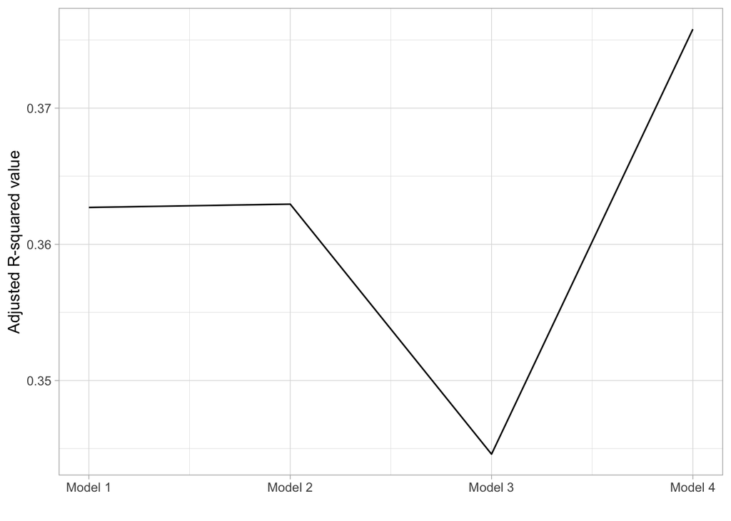

```r
all_models_Rsquared <- tibble(model = c(1, 2, 3, 4),
                   R_squared = c(summary(model_1)$adj.r.squared,
                                summary(model_2)$adj.r.squared,
                                summary(model_3)$adj.r.squared,
                                summary(model_4)$adj.r.squared))

ggplot(all_models_Rsquared, aes(x = model, y = R_squared)) +
  geom_line() +
  scale_x_continuous(name = "",
                   breaks = breaks <- seq(1, 4, by = 1),
                   labels = paste("Model", breaks)) +
  scale_y_continuous(name = "Adjusted R-squared value") +
  theme_light()
```

Table comparing initial linear regression model (model_1) with model with interaction term (model_4) because model 4 is the best fitting model based on its high adjusted R-squared value.

```r
coefficient_names <- c("Annual Rainfall (mm)" = "Total_Rainfall_mm",
                       "Annual Rainfall (mm)\n(log-transformed)" = "log(Total_Rainfall_mm)",
                 "Mean Annual Temperature (cels)" = "Mean_Temp_Celsius",
                 "Year with High Unemployment Rate\n(compared to year without high unemployment rate)" = "High_UnemploymentTRUE",
                 "Acres Burned" = "Acres_Burned",
                 "Year with Extreme Heat Wave\n(compared to year without extreme heat wave" = "Extreme_Heat_WaveTRUE",
"Interaction:\nextreme heat wave and\nlog-transformed annual rainfall" = "log(Total_Rainfall_mm):Extreme_Heat_WaveTRUE",
"Interaction:\nextreme heat wave and\nmean annual temperature (cels)" = "Mean_Temp_Celsius:Extreme_Heat_WaveTRUE",
"Interaction:\nextreme heat wave and\nyear with high unemployment rate" = "High_UnemploymentTRUE",
"Interaction:\nextreme heat wave and\nacres burned" = "Acres_Burned:Extreme_Heat_WaveTRUE")

export_summs(model_1, model_4,
             error_format = "(p = {p.value})",
             error_pos = "same",
             model.names = c("Initial model", "Preferred model"),
             coefs = coefficient_names)
```

|  | Initial model | Preferred model |
| --- | --- | --- |
| Annual Rainfall (mm) | -340.76 * (p = 0.01) |  |
| Annual Rainfall (mm) (log-transformed) |  | -256761.01 ** (p = 0.01) |
| Mean Annual Temperature (cels) | -23117.05 * (p = 0.03) | -20862.61 (p = 0.05) |
| Year with High Unemployment Rate (compared to year without high unemployment rate) | -3628.16 (p = 0.73) | 2221.25 (p = 0.84) |
| Acres Burned | 0.00 *** (p = 0.00) | 0.00 *** (p = 0.00) |
| Year with Extreme Heat Wave (compared to year without extreme heat wave | -10984.56 (p = 0.53) | -1625822.44 (p = 0.36) |
| Interaction: extreme heat wave and log-transformed annual rainfall |  | 310325.68 (p = 0.27) |
| Interaction: extreme heat wave and mean annual temperature (cels) |  | -44834.78 (p = 0.22) |
| Interaction: extreme heat wave and year with high unemployment rate |  |  |
| Interaction: extreme heat wave and acres burned |  | -0.00 (p = 0.16) |
| N | 87 | 87 |
| R2 | 0.40 | 0.44 |
| *** p < 0.001; ** p < 0.01; * p < 0.05. |  |  |